# PhoebeTeskey_Linear_Non-linear_Models_ENVS567

```r
library(ggplot2)
library(easystats)
library(DHARMa)
library(MASS)
library(lme4)
library(ecostats)
library(GGally)
library(car)
```

*Linear (and non-linear) Models*

*Question 1:* Data in growth.txt come from a farm-scale trial of animal diets. There are two factors: diet and supplement. Diet is a factor with three levels: barley, oats and wheat. Supplement is a factor with four levels: agrimore, control, supergain and supersupp. The response variable is weight gain after 6 weeks. Analyze the data following this structure: 1. Question, 2. Exploratory analyses, 3. Fit model, 4. Validate model, 5. Test hypothesis and assess explanatory power, and 6. Communication of results (plot + description of main results).

Question: What diet and supplement increases weight in mice after 6 weeks?

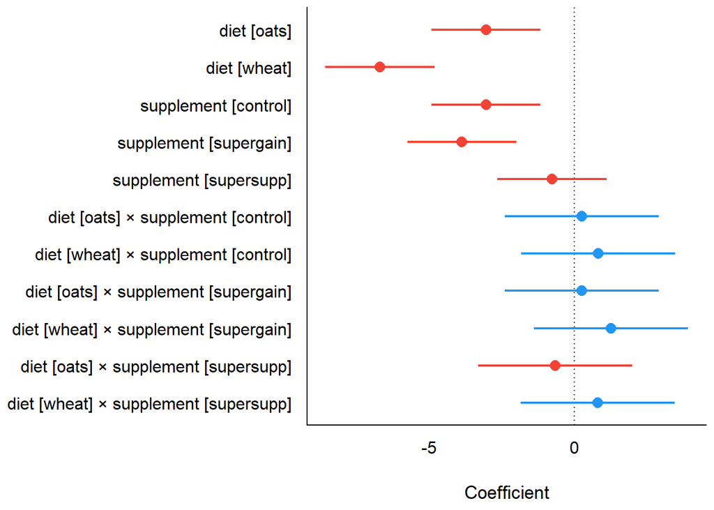

```r
#Exploratory analyses

growth <- read.table("../data_raw/growth.txt", header = T)
weight_gain_mice <- lm(gain ~ diet * supplement, data = growth)
plot(parameters(weight_gain_mice))
```

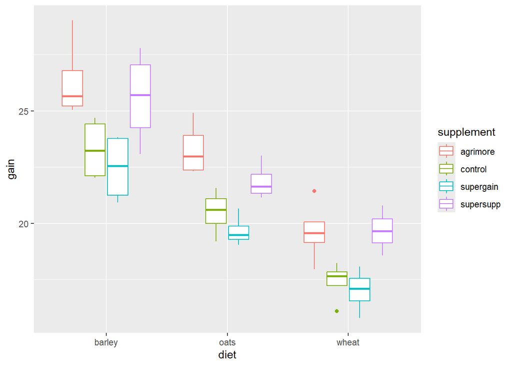

```r
ggplot(data = growth, aes(x = diet, y = gain, color = supplement))+
  geom_boxplot()
```

```r
#Fit model

model3 <- lm(gain ~ diet * supplement, data = growth)
summary(model3)
```

```
##
## Call:
## lm(formula = gain ~ diet * supplement, data = growth)
##
## Residuals:
##      Min       1Q   Median       3Q      Max
## -2.48756 -1.00368 -0.07452  1.03496  2.68069
##
## Coefficients:
##                               Estimate Std. Error t value Pr(>|t|)
## (Intercept)                    26.3485     0.6556  40.191  < 2e-16 ***
## dietoats                       -3.0501     0.9271  -3.290 0.002248 **
## dietwheat                      -6.7094     0.9271  -7.237 1.61e-08 ***
## supplementcontrol              -3.0518     0.9271  -3.292 0.002237 **
## supplementsupergain            -3.8824     0.9271  -4.187 0.000174 ***
## supplementsupersupp            -0.7732     0.9271  -0.834 0.409816
## dietoats:supplementcontrol      0.2471     1.3112   0.188 0.851571
## dietwheat:supplementcontrol     0.8183     1.3112   0.624 0.536512
## dietoats:supplementsupergain    0.2470     1.3112   0.188 0.851652
## dietwheat:supplementsupergain   1.2557     1.3112   0.958 0.344601
## dietoats:supplementsupersupp   -0.6650     1.3112  -0.507 0.615135
## dietwheat:supplementsupersupp   0.8024     1.3112   0.612 0.544381
## ---
## Signif. codes:  0 '***' 0.001 '**' 0.01 '*' 0.05 '.' 0.1 ' ' 1
##
## Residual standard error: 1.311 on 36 degrees of freedom
## Multiple R-squared:  0.8607, Adjusted R-squared:  0.8182
## F-statistic: 20.22 on 11 and 36 DF,  p-value: 3.295e-12
```

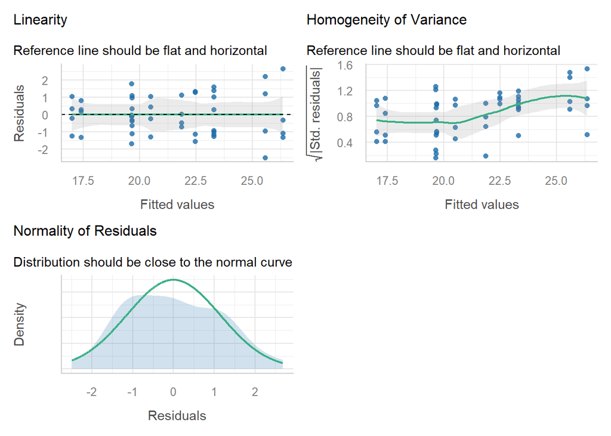

```r
#Validate model

check_model(model3, check=c("linearity", "homogeneity", "normality"))
```

```r
check_homogeneity(model3)
```

```
## OK: There is not clear evidence for different variances across groups (Bartlett Test, p = 0.817).
```

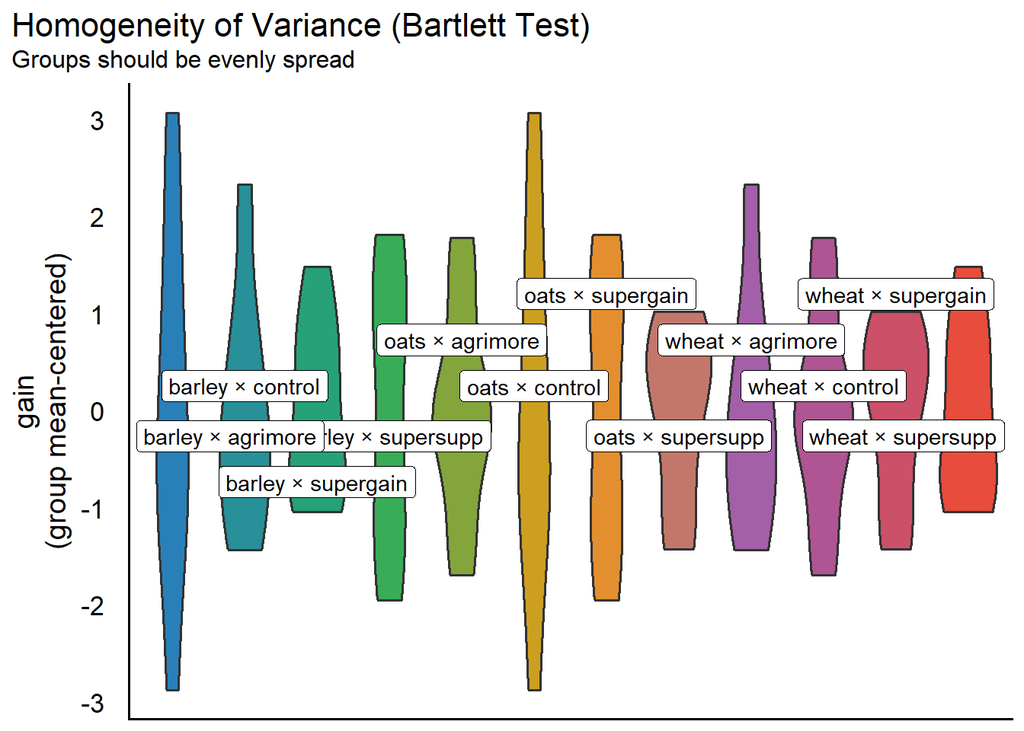

```r
plot(check_homogeneity(model3))
```

```r
#Test hypothesis and assess explanatory power
anova(model3)
```

```
## Analysis of Variance Table
##
## Response: gain
##                 Df  Sum Sq Mean Sq F value    Pr(>F)
## diet             2 287.171 143.586 83.5201 2.999e-14 ***
## supplement       3  91.881  30.627 17.8150 2.952e-07 ***
## diet:supplement  6   3.406   0.568  0.3302    0.9166
## Residuals       36  61.890   1.719
## ---
## Signif. codes:  0 '***' 0.001 '**' 0.01 '*' 0.05 '.' 0.1 ' ' 1
```

```r
#r^2
r2(model3)
```

```
## # R2 for Linear Regression
##        R2: 0.861
##   adj. R2: 0.818
```

Communication of results (plot + description of main results):

No significant interaction between diet and supplement. The effect of the supplements was consistent across diets. Type of diet was significant, (F2,36 = 83.52, p < 0.001) and the barley diet had a higher gain than barley or wheat. The supplement was also significant, (F3,36 = 17.8, p < 0.001). The model accounted for 82% of the variance in weight gain, (R2 = 0.82) with standard error at 1.31.

```r
model3.means <- estimate_means(model3)
```

```
## We selected `by=c("diet", "supplement")`.
```

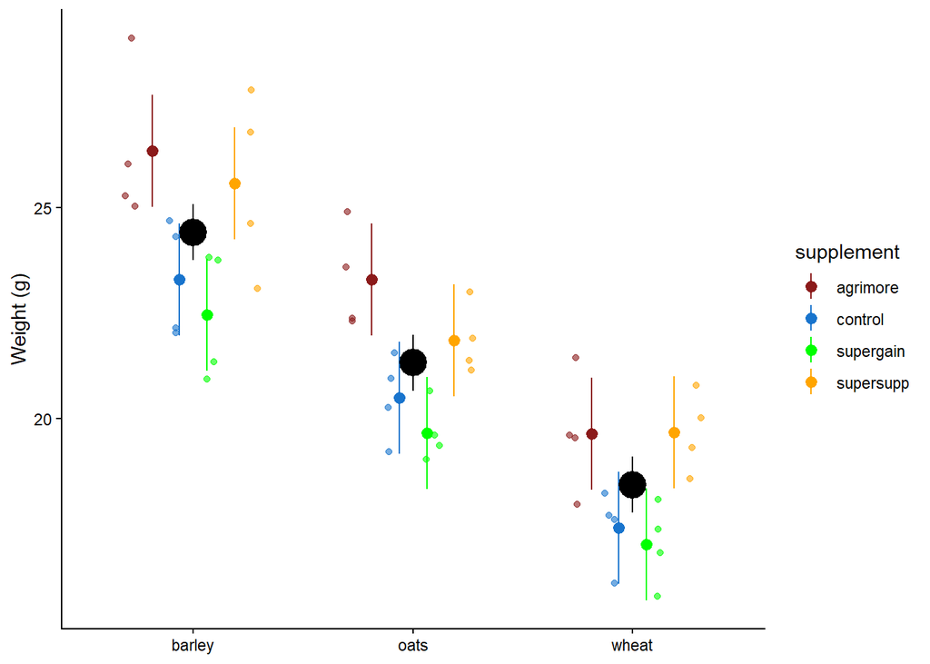

```r
amount.means <- estimate_means(model3, by = "diet")

ggplot(data = model3.means, aes(x = diet, y = Mean, color=supplement)) +
  geom_pointrange(aes(ymin = CI_low, ymax = CI_high), position=position_dodge(width=0.5), size=0.5) +
  geom_pointrange(data=amount.means, aes(ymin = CI_low, ymax = CI_high), position=position_dodge(width=0.5), size=1.5, color="black") +
  geom_jitter(data = growth, aes(x=diet, y=gain, color=supplement), alpha=0.6, size=1.5,
              position=position_jitterdodge(jitter.width = 0.2))+
  scale_color_manual(values = c("firebrick4", "dodgerblue3", "green", "orange"))+
  ylab("Weight (g)")+
  xlab(NULL)+
  theme_classic()
```

*Question #2:* Respiratory rate (Y) is expected to depend on body mass (X) by the power law, Y=aX, where  is the scaling exponent. The data are available in respiratoryrate_bodymass.txt.

1. Analyze the data by transforming the data and then fit a linear model.

```r
breathe <- read.table("../data_raw/respiratoryrate_bodymass.txt", header = T)
breathe$logBodyMass <- log(breathe$BodyMass)
breathe$logRespiration <- log(breathe$Respiration)

fit.log <- lm(logRespiration ~ logBodyMass, data = breathe)
summary(fit.log)
```

```
##
## Call:
## lm(formula = logRespiration ~ logBodyMass, data = breathe)
##
## Residuals:
##      Min       1Q   Median       3Q      Max
## -1.01062 -0.08150  0.00831  0.30669  0.43948
##
## Coefficients:
##             Estimate Std. Error t value Pr(>|t|)
## (Intercept)   1.3401     1.2011   1.116 0.296938
## logBodyMass   0.8574     0.1570   5.461 0.000601 ***
## ---
## Signif. codes:  0 '***' 0.001 '**' 0.01 '*' 0.05 '.' 0.1 ' ' 1
##
## Residual standard error: 0.4449 on 8 degrees of freedom
## Multiple R-squared:  0.7885, Adjusted R-squared:  0.762
## F-statistic: 29.82 on 1 and 8 DF,  p-value: 0.000601
```

For every 1% increase in body mass, the respiratory rate increases by approximately 0.86%

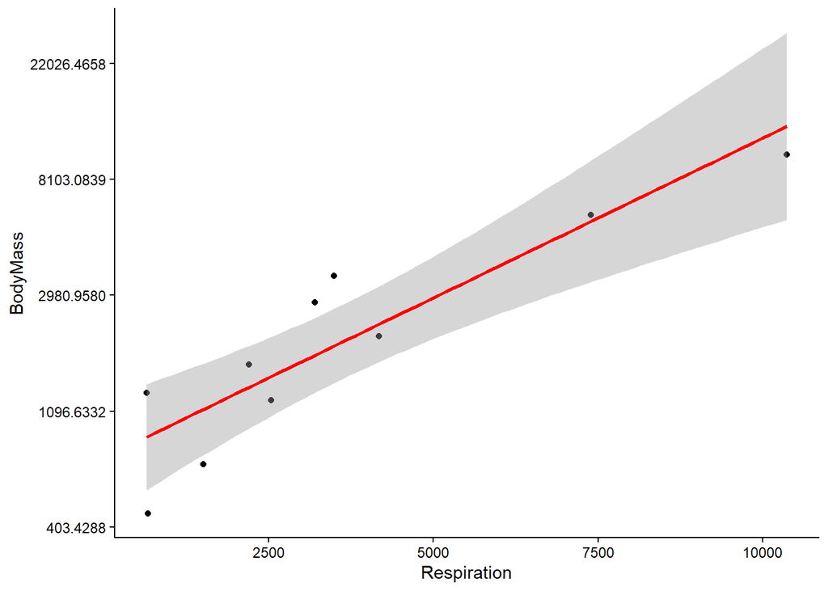

```r
ggplot(data = breathe, aes(x=Respiration, y=BodyMass))+
  geom_point()+
  geom_smooth(method ="lm", se = T, color = "red")+
  scale_y_continuous(trans = "log")+
  theme_classic()
```

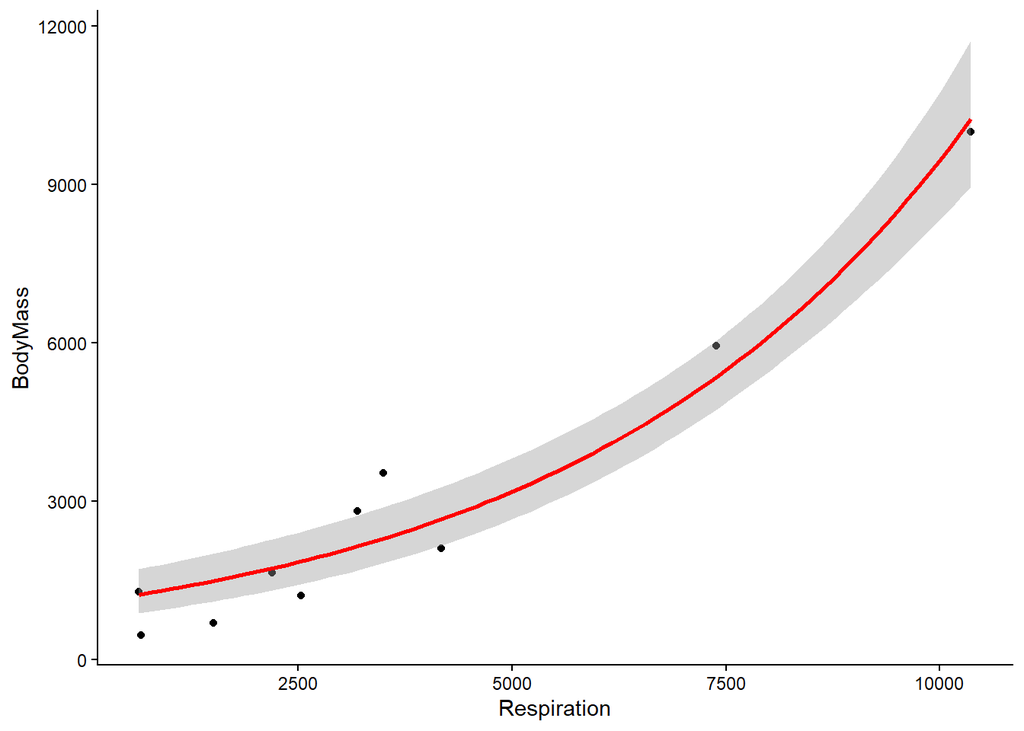

```r
ggplot(data = breathe, aes(x=Respiration, y=BodyMass))+
  geom_point()+
  geom_smooth(color= "red", method = "glm", method.args = list(family = gaussian(link = 'log')))+
  theme_classic()
```

*Question 3:* Use the diminish.txt data (xv is explanatory (independent), yv is response variable (dependent)) to perform a simple linear regression and a polynomial (second-degree) regression.

1. Compare both models and decide which model seems to be better?
2. Make a scatterplot and include both regression lines.

```r
diminish <- read.table("../data_raw/diminish.txt", header = T)

fit.lm <- lm(yv ~ xv, data=diminish)

fit.poly <- lm(yv ~ xv + I(xv^2), data=diminish)
summary(fit.poly)
```

```
##
## Call:
## lm(formula = yv ~ xv + I(xv^2), data = diminish)
##
## Residuals:
##     Min      1Q  Median      3Q     Max
## -4.0490 -1.2890  0.6018  1.1829  2.9610
##
## Coefficients:
##               Estimate Std. Error t value Pr(>|t|)
## (Intercept) 24.6323529  1.6916139  14.561 2.95e-10 ***
## xv           0.4057534  0.0819860   4.949 0.000175 ***
## I(xv^2)     -0.0018834  0.0008386  -2.246 0.040203 *
## ---
## Signif. codes:  0 '***' 0.001 '**' 0.01 '*' 0.05 '.' 0.1 ' ' 1
##
## Residual standard error: 2.131 on 15 degrees of freedom
## Multiple R-squared:  0.9046, Adjusted R-squared:  0.8919
## F-statistic: 71.12 on 2 and 15 DF,  p-value: 2.222e-08
```

```r
anova(fit.lm, fit.poly, test='LRT')
```

```
## Analysis of Variance Table
##
## Model 1: yv ~ xv
## Model 2: yv ~ xv + I(xv^2)
##   Res.Df    RSS Df Sum of Sq Pr(>Chi)
## 1     16 91.057
## 2     15 68.143  1    22.915  0.02471 *
## ---
## Signif. codes:  0 '***' 0.001 '**' 0.01 '*' 0.05 '.' 0.1 ' ' 1
```

```r
compare_performance(fit.lm, fit.poly)
```

```
## # Comparison of Model Performance Indices
##
## Name     | Model | AIC (weights) | AICc (weights) | BIC (weights) |    R2
## -------------------------------------------------------------------------
## fit.lm   |    lm |  86.3 (0.167) |   88.0 (0.283) |  88.9 (0.238) | 0.873
## fit.poly |    lm |  83.0 (0.833) |   86.1 (0.717) |  86.6 (0.762) | 0.905
##
## Name     | R2 (adj.) |  RMSE | Sigma
## ------------------------------------
## fit.lm   |     0.865 | 2.249 | 2.386
## fit.poly |     0.892 | 1.946 | 2.131
```

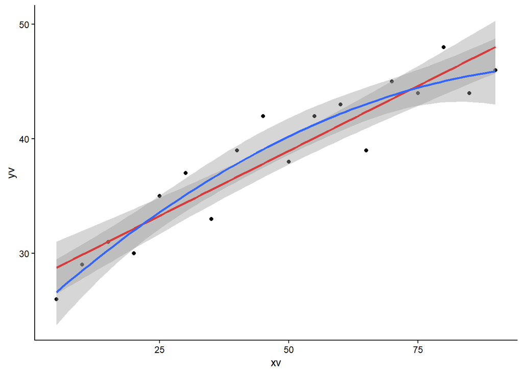

```r
ggplot(data=diminish, aes(x=xv, y=yv))+
  geom_point()+
  geom_smooth(method = "lm", se = T, color = "red")+
  geom_smooth(method = "lm", formula = y ~ poly(x,2), se = T)+
  theme_classic()
```

*Question 4* Use the ozone.txt data to model the ozone concentration as a linear additive (no interactions) function of wind speed, air temperature and the intensity of solar radiation.

1. Make a pairwise scatterplot and assess the collinearity of the explanatory variables

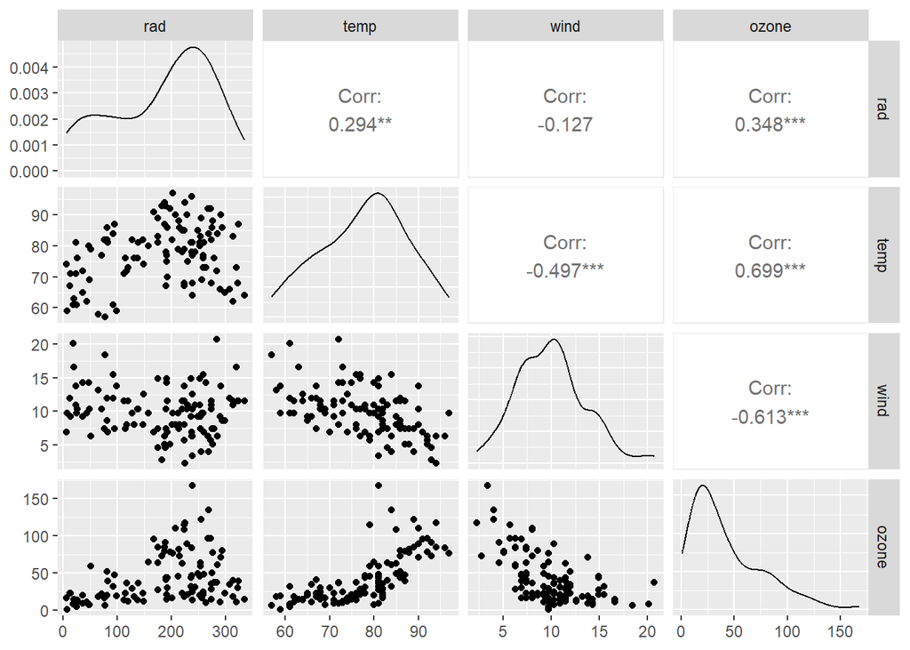

```r
ozone <- read.table("../data_raw/ozone.txt", header = T)

ggpairs(ozone)
```

```r
ozone.lm <- lm(ozone ~ rad+temp+wind, data=ozone)
summary(ozone.lm)
```

```
##
## Call:
## lm(formula = ozone ~ rad + temp + wind, data = ozone)
##
## Residuals:
##     Min      1Q  Median      3Q     Max
## -40.485 -14.210  -3.556  10.124  95.600
##
## Coefficients:
##              Estimate Std. Error t value Pr(>|t|)
## (Intercept) -64.23208   23.04204  -2.788  0.00628 **
## rad           0.05980    0.02318   2.580  0.01124 *
## temp          1.65121    0.25341   6.516 2.43e-09 ***
## wind         -3.33760    0.65384  -5.105 1.45e-06 ***
## ---
## Signif. codes:  0 '***' 0.001 '**' 0.01 '*' 0.05 '.' 0.1 ' ' 1
##
## Residual standard error: 21.17 on 107 degrees of freedom
## Multiple R-squared:  0.6062, Adjusted R-squared:  0.5952
## F-statistic: 54.91 on 3 and 107 DF,  p-value: < 2.2e-16
```

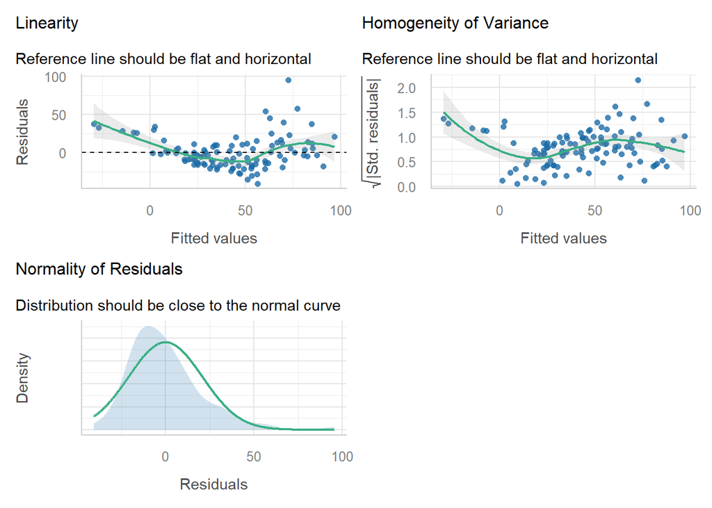

```r
check_model(ozone.lm, check=c("linearity", "homogeneity", "normality"))
```

```r
check_collinearity(ozone.lm)
```

```
## # Check for Multicollinearity
##
## Low Correlation
##
##  Term  VIF   VIF 95% CI adj. VIF Tolerance Tolerance 95% CI
##   rad 1.10 [1.01, 1.85]     1.05      0.91     [0.54, 0.99]
##  temp 1.43 [1.20, 1.92]     1.20      0.70     [0.52, 0.83]
##  wind 1.33 [1.14, 1.80]     1.15      0.75     [0.56, 0.88]
```

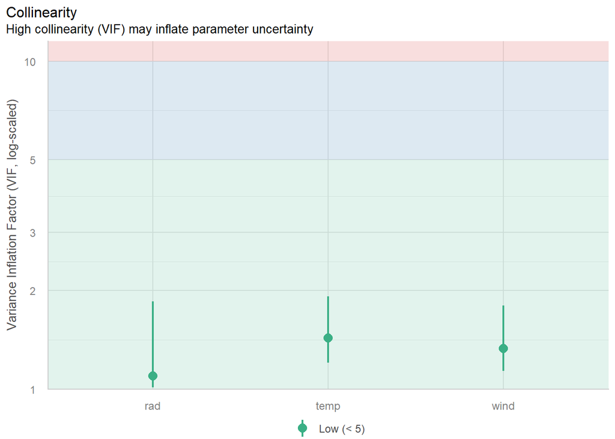

```r
plot(check_collinearity(ozone.lm))
```

```r
anova(ozone.lm)
```

```
## Analysis of Variance Table
##
## Response: ozone
##            Df Sum Sq Mean Sq F value    Pr(>F)
## rad         1  14780   14780  32.971 8.853e-08 ***
## temp        1  47378   47378 105.692 < 2.2e-16 ***
## wind        1  11680   11680  26.057 1.450e-06 ***
## Residuals 107  47964     448
## ---
## Signif. codes:  0 '***' 0.001 '**' 0.01 '*' 0.05 '.' 0.1 ' ' 1
```

```r
anova(lm(ozone ~ wind+rad+temp, data=ozone))
```

```
## Analysis of Variance Table
##
## Response: ozone
##            Df Sum Sq Mean Sq F value    Pr(>F)
## wind        1  45762   45762 102.088 < 2.2e-16 ***
## rad         1   9044    9044  20.176 1.792e-05 ***
## temp        1  19032   19032  42.457 2.429e-09 ***
## Residuals 107  47964     448
## ---
## Signif. codes:  0 '***' 0.001 '**' 0.01 '*' 0.05 '.' 0.1 ' ' 1
```

```r
anova(lm(ozone ~ wind+temp+rad, data=ozone))
```

```
## Analysis of Variance Table
##
## Response: ozone
##            Df Sum Sq Mean Sq  F value    Pr(>F)
## wind        1  45762   45762 102.0875 < 2.2e-16 ***
## temp        1  25092   25092  55.9759  2.16e-11 ***
## rad         1   2984    2984   6.6565   0.01124 *
## Residuals 107  47964     448
## ---
## Signif. codes:  0 '***' 0.001 '**' 0.01 '*' 0.05 '.' 0.1 ' ' 1
```

```r
Anova(ozone.lm, type = 2)
```

```
## Anova Table (Type II tests)
##
## Response: ozone
##           Sum Sq  Df F value    Pr(>F)
## rad         2984   1  6.6565   0.01124 *
## temp       19032   1 42.4567 2.429e-09 ***
## wind       11680   1 26.0567 1.450e-06 ***
## Residuals  47964 107
## ---
## Signif. codes:  0 '***' 0.001 '**' 0.01 '*' 0.05 '.' 0.1 ' ' 1
```

```r
r2(ozone.lm)
```

```
## # R2 for Linear Regression
##        R2: 0.606
##   adj. R2: 0.595
```

We explored the linear relationships between Ozone, Radiation, Wind and Temperature. Temperature and Radiation variables were positively associated with higher ozone levels (p-values < 0.05). Overall, our multiple regression model explained 60% (adjusted R2) of the variability in Ozone levels.

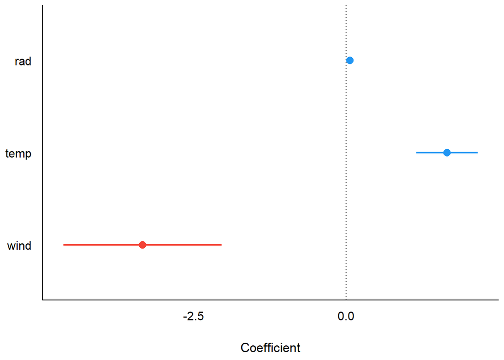

```r
plot(parameters(ozone.lm))
```

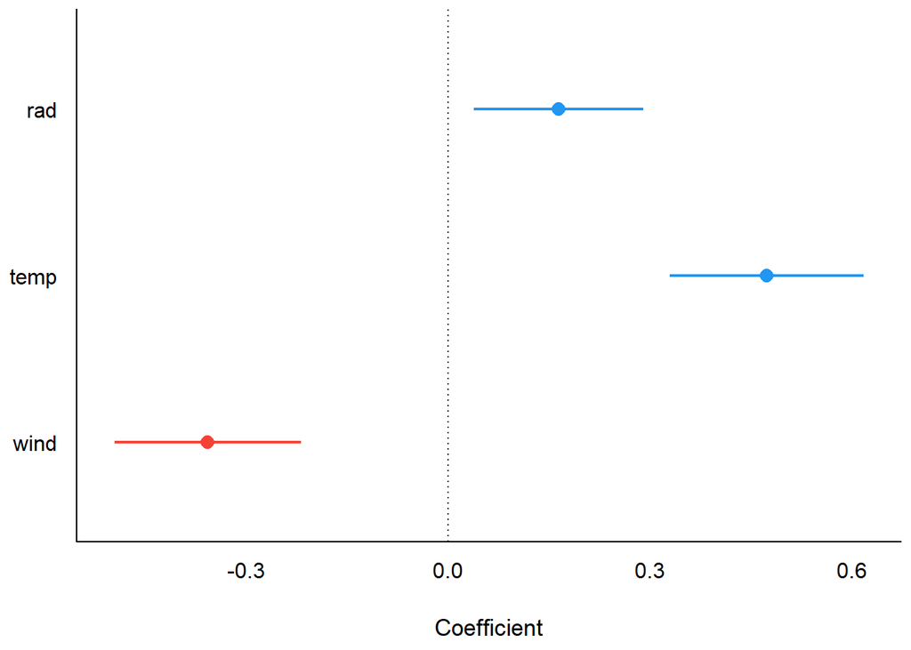

```r
plot(parameters(ozone.lm, standardize = "refit"))
```

*Question 5:* Use data(CO2) and assess the effects of the variables Treatment (categorical) and conc (ambient concentration, numerical) on the response uptake. Analyze the data following this structure: 1. Question, 2. Exploratory analyses, 3. Fit model, 4. Validate model, 5. Test hypothesis and assess explanatory power, and 6. Communication of results (plot + description of main results).

Question: Does ambient concentration of CO2 and treatment type affect uptake of CO2 in plants?

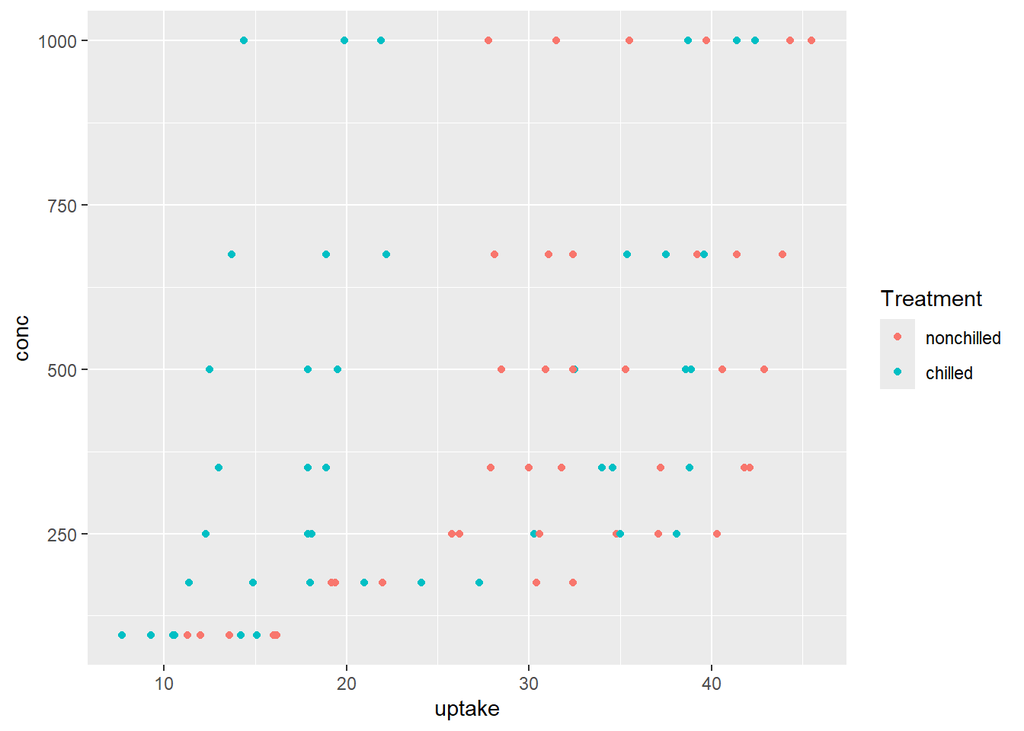

```r
#Exploratory analyses

data(CO2)

ggplot(CO2, aes(x = uptake, y = conc, color = Treatment)) +
  geom_point()
```

```r
#Fit model

model4 <- lm(uptake ~ Treatment * conc, data = CO2)
summary(model4)
```

```
##
## Call:
## lm(formula = uptake ~ Treatment * conc, data = CO2)
##
## Residuals:
##     Min      1Q  Median      3Q     Max
## -18.218  -7.401  -1.117   7.835  17.209
##
## Coefficients:
##                        Estimate Std. Error t value Pr(>|t|)
## (Intercept)           22.019163   2.464160   8.936 1.17e-13 ***
## Treatmentchilled      -5.037747   3.484848  -1.446    0.152
## conc                   0.019825   0.004693   4.225 6.29e-05 ***
## Treatmentchilled:conc -0.004188   0.006636  -0.631    0.530
## ---
## Signif. codes:  0 '***' 0.001 '**' 0.01 '*' 0.05 '.' 0.1 ' ' 1
##
## Residual standard error: 8.946 on 80 degrees of freedom
## Multiple R-squared:  0.3405, Adjusted R-squared:  0.3157
## F-statistic: 13.77 on 3 and 80 DF,  p-value: 2.528e-07
```

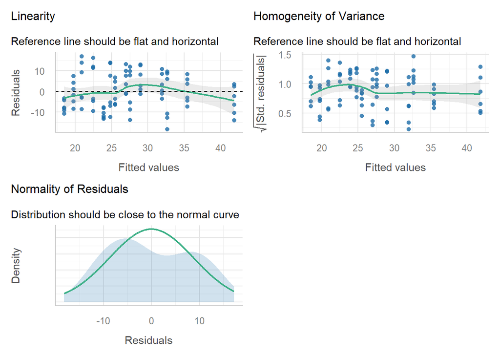

```r
#Validate model

check_model(model4, check=c("linearity", "homogeneity", "normality"))
```

```r
#Test hypothesis and assess explanatory power

anova(model4)
```

```
## Analysis of Variance Table
##
## Response: uptake
##                Df Sum Sq Mean Sq F value    Pr(>F)
## Treatment       1  988.1  988.11 12.3476 0.0007297 ***
## conc            1 2285.0 2284.99 28.5535 8.377e-07 ***
## Treatment:conc  1   31.9   31.87  0.3983 0.5297890
## Residuals      80 6402.0   80.02
## ---
## Signif. codes:  0 '***' 0.001 '**' 0.01 '*' 0.05 '.' 0.1 ' ' 1
```

```r
Anova(model4)
```

```
## Anova Table (Type II tests)
##
## Response: uptake
##                Sum Sq Df F value    Pr(>F)
## Treatment       988.1  1 12.3476 0.0007297 ***
## conc           2285.0  1 28.5535 8.377e-07 ***
## Treatment:conc   31.9  1  0.3983 0.5297890
## Residuals      6402.0 80
## ---
## Signif. codes:  0 '***' 0.001 '**' 0.01 '*' 0.05 '.' 0.1 ' ' 1
```

```r
r2(model4)
```

```
## # R2 for Linear Regression
##        R2: 0.340
##   adj. R2: 0.316
```

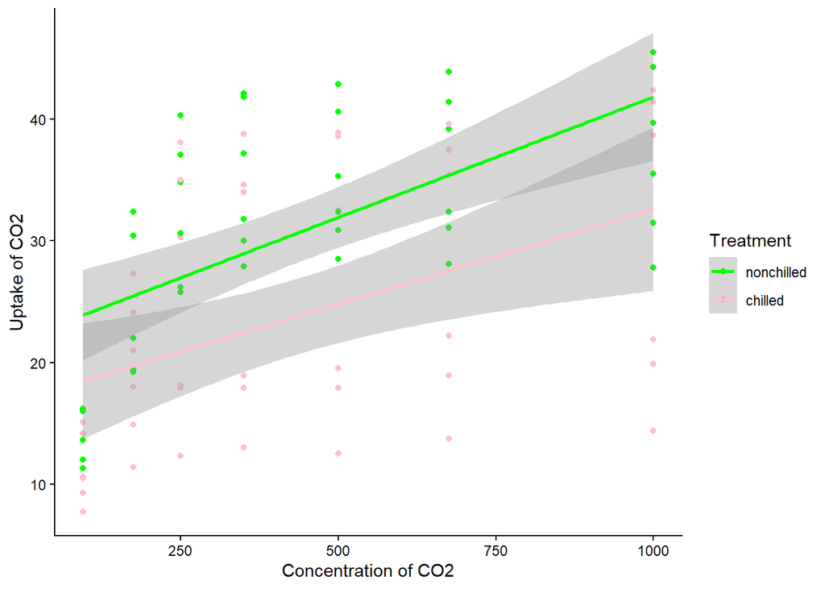

```r
#Communicate results with a plot
ggplot(CO2, aes(y=uptake, x=conc, color=Treatment))+
  geom_point()+
  geom_smooth(method = "lm", se = T)+
  scale_color_manual(values = c("green", "pink"))+
  ylab("Uptake of CO2")+
  xlab("Concentration of CO2")+
  theme_classic()
```

*Question 6*: Use the jaws.txt data (age explanatory, bone response).

[output not shown]

```r
jaws <- read.table("../data_raw/jaws.txt", header = T)

jaws.asymp<-nls(bone~a*age/(b+age), start=list(a=100, b=0.1), data=jaws)
summary(jaws.asymp)
```

```
##
## Formula: bone ~ a * age/(b + age)
##
## Parameters:
##   Estimate Std. Error t value Pr(>|t|)
## a  137.723      5.965  23.089  < 2e-16 ***
## b    7.355      1.277   5.757 4.91e-07 ***
## ---
## Signif. codes:  0 '***' 0.001 '**' 0.01 '*' 0.05 '.' 0.1 ' ' 1
##
## Residual standard error: 13.9 on 51 degrees of freedom
##
## Number of iterations to convergence: 7
## Achieved convergence tolerance: 2.912e-06
```

```r
summary(nls(bone ~ SSmicmen(age, a, b), data=jaws))
```

```
##
## Formula: bone ~ SSmicmen(age, a, b)
##
## Parameters:
##   Estimate Std. Error t value Pr(>|t|)
## a  137.723      5.965  23.089  < 2e-16 ***
## b    7.355      1.277   5.757 4.91e-07 ***
## ---
## Signif. codes:  0 '***' 0.001 '**' 0.01 '*' 0.05 '.' 0.1 ' ' 1
##
## Residual standard error: 13.9 on 51 degrees of freedom
##
## Number of iterations to convergence: 0
## Achieved convergence tolerance: 1.7e-06
```

```r
rss<-13.9^2*51 # residual sum of squares

null<-lm(bone~1, data=jaws) # null model with only a constant
summary(null)
```

```
##
## Call:
## lm(formula = bone ~ 1, data = jaws)
##
## Residuals:
##     Min      1Q  Median      3Q     Max
## -85.751  -9.979   9.464  20.324  46.248
##
## Coefficients:
##             Estimate Std. Error t value Pr(>|t|)
## (Intercept)    95.75       4.26   22.48   <2e-16 ***
## ---
## Signif. codes:  0 '***' 0.001 '**' 0.01 '*' 0.05 '.' 0.1 ' ' 1
##
## Residual standard error: 31.01 on 52 degrees of freedom
```

```r
tss<-31.01^2*52 # total sum of squares

100*(tss-rss)/tss
```

```
## [1] 80.29425
```

```r
fit_mm <- nls(bone ~ a * age / (1 + b * age),
              data = jaws,
              start = list(a = 20, b = 0.1))

aic_asymp <- AIC(jaws.asymp)
aic_mm <- AIC(fit_mm)

summary(aic_asymp)
```

```
##    Min. 1st Qu.  Median    Mean 3rd Qu.    Max.
##   433.4   433.4   433.4   433.4   433.4   433.4
```

```r
summary(aic_mm)
```

```
##    Min. 1st Qu.  Median    Mean 3rd Qu.    Max.
##   433.4   433.4   433.4   433.4   433.4   433.4
```

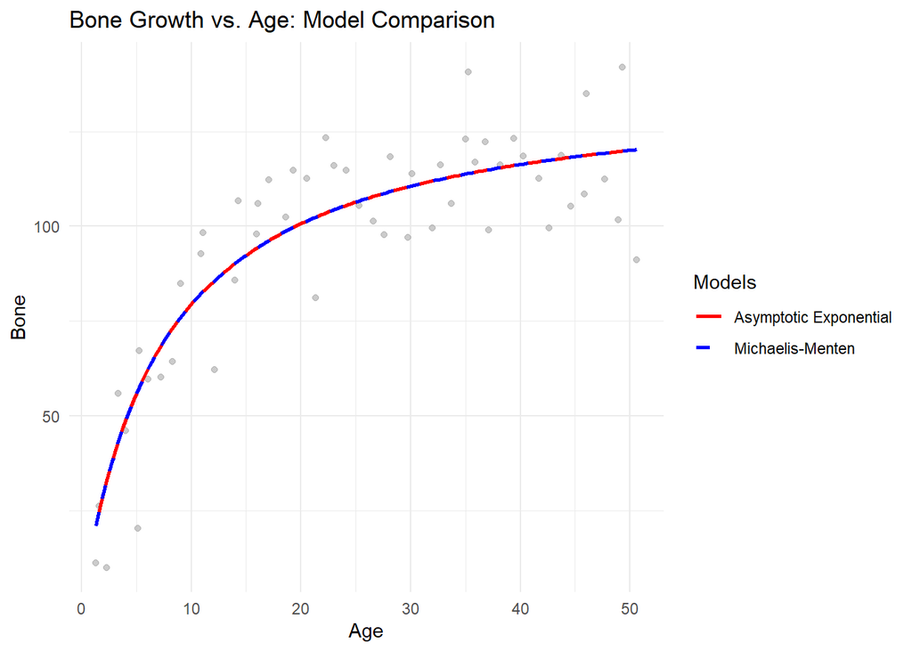

```r
age_range <- data.frame(age = seq(min(jaws$age), max(jaws$age), length.out = 200))

age_range$asymp_pred <- predict(jaws.asymp, newdata = age_range)
age_range$mm_pred <- predict(fit_mm, newdata = age_range)

ggplot(jaws, aes(x = age, y = bone)) +
  geom_point(alpha = 0.6, color = "darkgrey") +
  # Add Asymptotic Exponential line
  geom_line(data = age_range, aes(y = asymp_pred, color = "Asymptotic Exponential"), size = 1) +
  # Add Michaelis-Menten line
  geom_line(data = age_range, aes(y = mm_pred, color = "Michaelis-Menten"), size = 1, linetype = "dashed") +
  # Formatting
  scale_color_manual(name = "Models", values = c("Asymptotic Exponential" = "red", "Michaelis-Menten" = "blue")) +
  labs(title = "Bone Growth vs. Age: Model Comparison",
       x = "Age",
       y = "Bone") +
  theme_minimal()
```